# Part II - Factors that influence loan amount disbursed to borrowers

## by Fidelia Tubonibo

## Investigation Overview

> This presentation highlights the factors that influence the loan amount borrowers were able to access and the status of loans collected. It also explores the trend of loan collection across time.

## Dataset Overview

> This dataset contains loan and borrower data from 113,937 loans listings in the USA. There are 113,937 loan entries with 81 variables on each loan in this dataset. Most variables are numeric in nature, but other data types include: category, string, integer, float, boolean and datetime. Two columns were extracted from the "listing creation date" column into separate columns named "Year" and "Quarter"

## Distribution of Loan Amount

The loan amount vary between 1,000 USD and 35,000 USD. The loan amount with the highest borrower count is 4,000 USD. Across the loan amounts, fewer borrowers request a high loan amount.

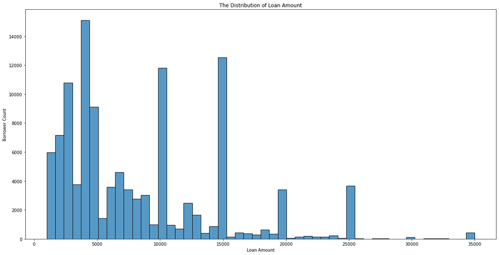

## Relationship between Loan amount and (a)Employment Status (b) Income Range

### a) Loan amount and Employment Status

Borrowers who are employed have access to high loan amounts while people who work part-time have access to the least loan amounts.

### b) Loan amount and Income range

The income range of borrowers further gives insight to the amount of loans they have access to. High earning borrowers have access to loans of higher amounts as opposed to people who earn less.

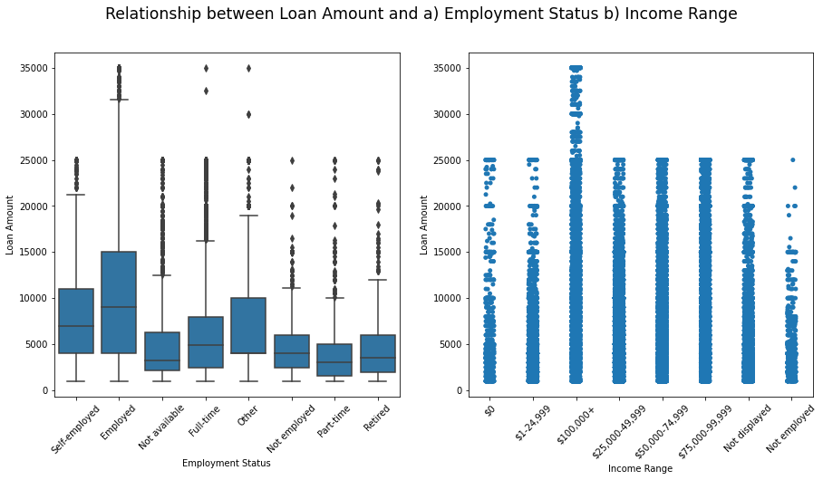

## Relationship between Income range and borrower APR

Here we see how the income range of borrowers affect the annual principal rate on loans collected. Borrowers who are not employed are seen to have the highest APR while people who earn above 100k USD have the least. This implies that high earners are able to remit their annual interest better than low income earners.

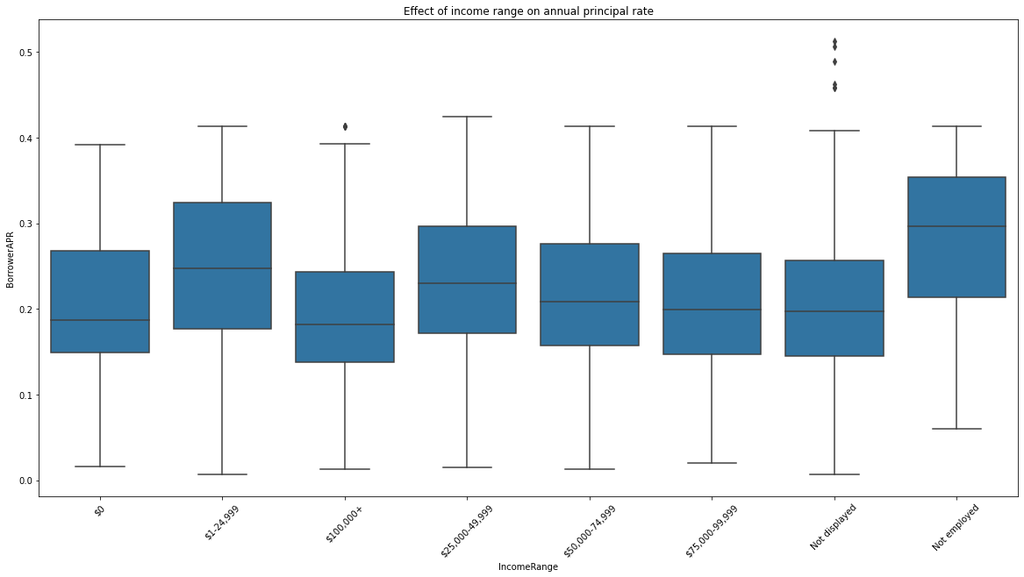

## How does loan amount change with every quarter in each year?

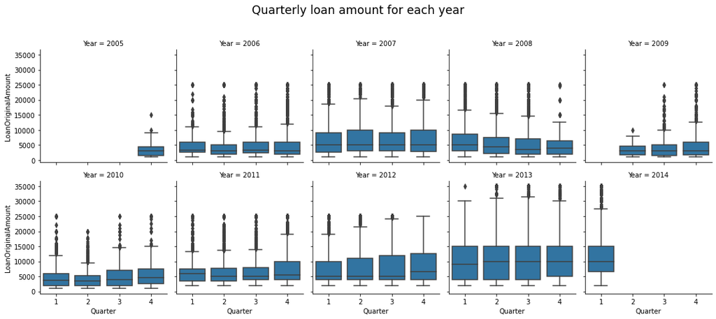